# Probability.Results.BASE

Sabrina Xie

Last compiled 23 February, 2022, 14:04:12

# Probability analysis

## Load packages

```r
library(tidyverse)
library(huxtable)
library(ggplot2)
library(lubridate)
library(spsurvey) #This code was written for spsurvey v5.0.0
```

## Load data

To run cat_analysis(), the dataframe will need to include columns for the categorical variable you are interested in, weight for each site, xcoordinate and ycoordinate. Optionally, you can also include a subpopulation or stratum column to separate results and site IDs for two-stage analysis (for example, if there are repeated sites).

In this script, weight is adjusted because of the proportional design. In the future, this can be excluded as the design should include weights already.

I am designating relevant variables from the dataset as well as creating new variables: mean dissolved oxygen from 0-2m, epilimentic means for ph and spconductance, total nitrogen and DIN:TP ratio.

```r
# retrieve raw data from database
setwd("~/OneDrive - New York State Office of Information Technology Services/Rscripts/Current")
source("new_database/Reading.LMAS.Data.R")
setwd("~/OneDrive - New York State Office of Information Technology Services/Rscripts/Probability.Sampling/")

rm(list=setdiff(ls(), c('newdata')))
```

```r
#list relevant variables
lab<-newdata %>%
  filter(SAMPLE_DATE>'2020-01-01') %>%
  mutate(combined=paste(CHARACTERISTIC_NAME,
                        INFORMATION_TYPE,
                        RSLT_RESULT_SAMPLE_FRACTION,
                        sep = "_"))  %>%
  select(LAKE_HISTORY_ID,
         SAMPLE_DATE,
         combined,
         RSLT_RESULT_VALUE,
         RSLT_LABORATORY_QUALIFIER,
         RSLT_VALIDATOR_QUALIFIER,
         RSLT_PROFILE_DEPTH) %>%
  mutate(RSLT_RESULT_VALUE=ifelse(!is.na(RSLT_LABORATORY_QUALIFIER)&(RSLT_LABORATORY_QUALIFIER=="U"|RSLT_LABORATORY_QUALIFIER=="UE"),"0",RSLT_RESULT_VALUE),
         RSLT_RESULT_VALUE=as.numeric(RSLT_RESULT_VALUE)) %>%
  filter(!is.na(RSLT_RESULT_VALUE),
         is.na(RSLT_VALIDATOR_QUALIFIER)|(RSLT_VALIDATOR_QUALIFIER!="R"),
         combined %in% c('CHLOROPHYLL A_OW_TOTAL',
                         'PHOSPHORUS, TOTAL_OW_TOTAL',
                         "MICROCYSTIN_OW_NA",
                         "NITROGEN, NITRATE (AS N)_OW_TOTAL",
                         "NITROGEN, NITRATE-NITRITE_OW_TOTAL",
                         "NITROGEN, KJELDAHL, TOTAL_OW_TOTAL",
                         "NITROGEN, TOTAL_OW_TOTAL",
                         "DISSOLVED OXYGEN_DP_NA",
                         "TRUE COLOR_OW_TOTAL",
                         "PH_DP_NA",
                         "SPECIFIC CONDUCTANCE_DP_NA",
                         "TEMPERATURE_DP_NA",
                         "DEPTH, SECCHI DISK DEPTH_SD_NA",
                         "CALCIUM_OW_TOTAL",
                         "CHLORIDE_OW_TOTAL",
                         "CHLOROPHYLL A (PROBE) CONCENTRATION, CHLOROPHYTE (GREEN ALGAE)_OW_NA",
                         "CHLOROPHYLL A (PROBE) CONCENTRATION, CRYPTOPHYTA (CRYPTOPHYTES)_OW_NA",
                         "CHLOROPHYLL A (PROBE) CONCENTRATION, CYANOBACTERIA (BLUEGREEN)_OW_NA",
                         "CHLOROPHYLL A (PROBE) CONCENTRATION, DINOPHYTA (DIATOMS)_OW_NA",
                         "CHLOROPHYLL A (PROBE) CONCENTRATION, TOTAL_OW_NA",
                         "ALKALINITY, TOTAL (AS CACO3)_OW_TOTAL")) %>%
  select(LAKE_HISTORY_ID,SAMPLE_DATE,combined,RSLT_RESULT_VALUE,RSLT_PROFILE_DEPTH) %>%
  distinct(LAKE_HISTORY_ID,SAMPLE_DATE,combined,RSLT_PROFILE_DEPTH,.keep_all = TRUE) %>%
  rename(LAKE_ID=LAKE_HISTORY_ID,
         chemical_name=combined,
         result_value=RSLT_RESULT_VALUE,
         profile_depth=RSLT_PROFILE_DEPTH)

   # dissolved oxygen:
   # keep DO values between 0 and 2m depth
lab2 <- lab %>%
   mutate(keep=case_when(
     !(chemical_name=="DISSOLVED OXYGEN_DP_NA") ~ "no",
     chemical_name=="DISSOLVED OXYGEN_DP_NA" & profile_depth <= 2 ~ "yes",
     chemical_name=="DISSOLVED OXYGEN_DP_NA" & profile_depth > 2 ~ "no")) %>%
   filter(keep!="no") %>%
   select(-keep)

# mean DO for each lake each date
DO <- aggregate(lab2$result_value,list(lab2$LAKE_ID,lab2$SAMPLE_DATE),FUN=mean) %>%
  mutate(chemical_name="DISSOLVED OXYGEN_epi") %>%
  rename(LAKE_ID=Group.1,
         SAMPLE_DATE=Group.2,
         result_value=x)

#thermocline
thermocline<-lab %>%
  filter(chemical_name=='TEMPERATURE_DP_NA') %>%
  mutate(thermocline=NA)
LID<-thermocline$LAKE_ID[1]
date<-thermocline$SAMPLE_DATE[1]
depth<-thermocline$profile_depth[1]
temp<-thermocline$result_value[1]

for(i in seq(nrow(thermocline))){
  current<-thermocline[i,]
  if(current$LAKE_ID==LID&current$SAMPLE_DATE==date){
      depth=current$profile_depth
      if((temp-current$result_value)>1){
        thermocline$thermocline[i]<-current$profile_depth
      }
      temp=current$result_value
  }
  else{
    LID=current$LAKE_ID
    date=current$SAMPLE_DATE
    depth=current$profile_depth
    temp=current$result_value
  }
}

thermocline<-thermocline %>%  #pull the lowest value for all
  group_by(LAKE_ID,SAMPLE_DATE) %>%
  mutate(thermocline=min(thermocline, na.rm=T)) %>%
  ungroup() %>%
  mutate(thermocline=ifelse(thermocline==Inf,NA,thermocline)) %>%
  select(LAKE_ID,SAMPLE_DATE,thermocline,profile_depth) %>%
  filter(!is.na(thermocline)) %>%   #remove those without a thermocline
  distinct()

#epilimentic means for ph and spconductance
epi<-lab %>%
  inner_join(thermocline,by=c('LAKE_ID','SAMPLE_DATE','profile_depth')) %>%
  filter(chemical_name %in% c("PH_DP_NA","SPECIFIC CONDUCTANCE_DP_NA")) %>%
  mutate(result_value = ifelse(chemical_name=="PH_DP_NA",(10^result_value),result_value)) %>%
  distinct() %>%
  arrange(LAKE_ID,SAMPLE_DATE,chemical_name,profile_depth)

epi<-epi %>%
  filter(profile_depth<=thermocline) %>%
  distinct() %>%
  group_by(LAKE_ID,SAMPLE_DATE,chemical_name) %>%
  summarize(Mean=mean(result_value,na.rm=TRUE),
            n=n()) %>%
  filter(n>2) %>%
  select(LAKE_ID,SAMPLE_DATE,chemical_name,Mean)

epi<-epi %>%
  mutate(Mean=ifelse(chemical_name=="PH_DP_NA",log10(Mean),Mean)) %>%
  rename(result_value=Mean) %>%
  mutate(chemical_name=case_when(
    chemical_name=="PH_DP_NA"~"PH_epi",
    chemical_name=="SPECIFIC CONDUCTANCE_DP_NA"~"SPECIFIC CONDUCTANCE_epi"
  ))

# read in site data
sites<-read.csv("Probability_Based_Sites_2020_2021.csv")
sites<-sites %>%
  rename(siteID=SITE_ID,
         xcoord=LON_DD83,
         ycoord=LAT_DD83,
         Eval_Status=EvalStatus) %>%
  filter(Eval_Status!="") %>%    #removing sites that we haven't yet evaluated
  mutate(Eval_Status=trimws(Eval_Status))

# restrict to only the data in the probability study and spread the data
att<-merge(lab,epi,by=c("LAKE_ID","SAMPLE_DATE","chemical_name"),all=TRUE) %>%
  mutate(result_value=ifelse(is.na(result_value.x),result_value.y,result_value.x)) %>%
  select(-result_value.x,-result_value.y)
att<-merge(att,DO,by=c("LAKE_ID","SAMPLE_DATE","chemical_name"),all=TRUE)%>%
  mutate(result_value=ifelse(is.na(result_value.x),result_value.y,result_value.x)) %>%
  filter(!chemical_name %in% c("DISSOLVED OXYGEN_DP_NA","PH_DP_NA","SPECIFIC CONDUCTANCE_DP_NA","TEMPERATURE_DP_NA")) %>%
  select(-result_value.x,-result_value.y)

att<-merge(att,sites,by=c('LAKE_ID'),all.y = TRUE) %>% distinct()
att<-att %>% spread(chemical_name,result_value,fill = NA)
```

```r
att<-att %>% filter((Eval_Status=="Target_Sampled"&!is.na(`CHLOROPHYLL A_OW_TOTAL`)&!is.na(`PHOSPHORUS, TOTAL_OW_TOTAL`)) |
                      (Eval_Status!="Target_Sampled") |
                      (LAKE_ID %in% c("0703UWBXXX1","0801KAY0984A","1203MET0821","0602LUD0099","0801GUL0969")))

#creating thresholds
att<-att %>%
  # remove fields in the sites table that aren't relevant
  select(-Accessible,-Comments,-Contact,-STATUS) %>%
  # create total nitrogen
  mutate(`NITROGEN, TOTAL`=case_when(
    !is.na(`NITROGEN, KJELDAHL, TOTAL_OW_TOTAL`) ~
      (`NITROGEN, NITRATE-NITRITE_OW_TOTAL`+`NITROGEN, KJELDAHL, TOTAL_OW_TOTAL`),
    is.na(`NITROGEN, KJELDAHL, TOTAL_OW_TOTAL`) ~ `NITROGEN, TOTAL_OW_TOTAL`)) %>%
  # DIN:TP
  mutate(DINTP=`NITROGEN, NITRATE (AS N)_OW_TOTAL`/`PHOSPHORUS, TOTAL_OW_TOTAL`) %>%
  # trophic status
  mutate(phos_trophic=case_when(
    `PHOSPHORUS, TOTAL_OW_TOTAL`<=0.01 ~ "Oligotrophic",
    between(`PHOSPHORUS, TOTAL_OW_TOTAL`,0.01,0.02) ~ "Mesotrophic",
    `PHOSPHORUS, TOTAL_OW_TOTAL`>=0.02 ~ "Eutrophic")) %>%
  mutate(chla_trophic=case_when(
    `CHLOROPHYLL A_OW_TOTAL`<=2 ~ "Oligotrophic",
    between(`CHLOROPHYLL A_OW_TOTAL`,2,8) ~ "Mesotrophic",
    `CHLOROPHYLL A_OW_TOTAL`>=8 ~ "Eutrophic")) %>%
  # EPA thresholds
  mutate(TP_threshold=case_when(
    `PHOSPHORUS, TOTAL_OW_TOTAL`<=0.016 ~ "Good",
    between(`PHOSPHORUS, TOTAL_OW_TOTAL`, 0.016, 0.0279) ~ "Fair",
    `PHOSPHORUS, TOTAL_OW_TOTAL`>=0.0279 ~ "Poor")) %>%
  mutate(TN_threshold=case_when(
    `NITROGEN, TOTAL`<=0.428 ~ "Good",
    between(`NITROGEN, TOTAL`, 0.428, 0.655) ~ "Fair",
    `NITROGEN, TOTAL`>=0.655 ~ "Poor")) %>%
  mutate(CHLA_threshold=case_when(
    `CHLOROPHYLL A_OW_TOTAL`<=4.52 ~ "Good",
    between(`CHLOROPHYLL A_OW_TOTAL`, 4.52, 8.43) ~ "Fair",
    `CHLOROPHYLL A_OW_TOTAL`>=8.43 ~ "Poor")) %>%
  # microcystin
  mutate(microcystin=case_when(
    is.na(`MICROCYSTIN_OW_NA`) ~"Non-detect",
    `MICROCYSTIN_OW_NA`<8 ~ "Microcystin Detected",
    `MICROCYSTIN_OW_NA`>=8 ~ "Most disturbed")) %>%
  # dissolved oxygen
  mutate(d.oxygen=case_when(
    `DISSOLVED OXYGEN_epi`<=3 ~ "Poor",
    between(`DISSOLVED OXYGEN_epi`, 3, 5) ~ "Fair",
    `DISSOLVED OXYGEN_epi`>=5 ~ "Good")) %>%
  #nutrient limitation
  mutate(N_LIMIT=case_when(
    `NITROGEN, TOTAL`/`PHOSPHORUS, TOTAL_OW_TOTAL`<=10 ~ "N-limited",
    between(`NITROGEN, TOTAL`/`PHOSPHORUS, TOTAL_OW_TOTAL`, 10, 20) ~ "Co-limited",
    `NITROGEN, TOTAL`/`PHOSPHORUS, TOTAL_OW_TOTAL`>=20 ~ "P-limited")) %>%
  #secchi
  mutate(secchi=case_when(
    `DEPTH, SECCHI DISK DEPTH_SD_NA`<=2 ~ "Eutrophic",
    between(`DEPTH, SECCHI DISK DEPTH_SD_NA`, 2, 5) ~ "Mesotrophic",
    `DEPTH, SECCHI DISK DEPTH_SD_NA`>=5 ~ "Oligotrophic")) %>%
  #zebra mussels
  mutate(zebra=case_when(
    CALCIUM_OW_TOTAL<=10 ~ "Not susceptible",
    between(CALCIUM_OW_TOTAL, 10, 20) ~ "May be susceptible",
    CALCIUM_OW_TOTAL>=20 ~ "Highly susceptible")) %>%
  #cslap
  mutate(conductance=case_when(
    `SPECIFIC CONDUCTANCE_epi`<=125 ~ "Soft",
    between(`SPECIFIC CONDUCTANCE_epi`, 125, 250) ~ "Average",
    `SPECIFIC CONDUCTANCE_epi`>=250 ~ "Hard")) %>%
  mutate(color=case_when(
    `TRUE COLOR_OW_TOTAL`<=10 ~ "Uncolored",
    between(`TRUE COLOR_OW_TOTAL`, 10, 30) ~ "Weak",
    `TRUE COLOR_OW_TOTAL`>=30 ~ "High")) %>%
  mutate(ph=case_when(
    `PH_epi`<=6.5 ~ "Acidic",
    between(`PH_epi`, 6.5, 7.5) ~ "~Neutral",
    between(`PH_epi`, 7.5, 8.5) ~ "Slightly alk",
    `PH_epi`>=8.5 ~ "Highly alk")) %>%
  #leech
  mutate(leech=case_when(
    `PHOSPHORUS, TOTAL_OW_TOTAL`<=0.030 & `TRUE COLOR_OW_TOTAL`<=20 ~ "Blue",
    `PHOSPHORUS, TOTAL_OW_TOTAL`>0.030 & `TRUE COLOR_OW_TOTAL`<=20 ~ "Green",
    `PHOSPHORUS, TOTAL_OW_TOTAL`<=0.030 & `TRUE COLOR_OW_TOTAL`>20 ~ "Brown",
    `PHOSPHORUS, TOTAL_OW_TOTAL`>0.030 & `TRUE COLOR_OW_TOTAL`>20 ~ "Murky"
  )) %>%
  #chloride
  mutate(chloride=case_when(
    `CHLORIDE_OW_TOTAL` <= 35 ~ "Low",
    between(`CHLORIDE_OW_TOTAL`,35,250) ~ "Medium",
    `CHLORIDE_OW_TOTAL` >= 250 ~ "High",
    Eval_Status=="Target_Sampled" & is.na(`CHLORIDE_OW_TOTAL`) ~ "Low")) %>%
  #chlorophyll
  rename(CHLOROPHYTE=`CHLOROPHYLL A (PROBE) CONCENTRATION, CHLOROPHYTE (GREEN ALGAE)_OW_NA`,
         CRYPTOPHYTA=`CHLOROPHYLL A (PROBE) CONCENTRATION, CRYPTOPHYTA (CRYPTOPHYTES)_OW_NA`,
         CYANOBACTERIA=`CHLOROPHYLL A (PROBE) CONCENTRATION, CYANOBACTERIA (BLUEGREEN)_OW_NA`,
         DINOPHYTA=`CHLOROPHYLL A (PROBE) CONCENTRATION, DINOPHYTA (DIATOMS)_OW_NA`,
         PROBE_TOTAL=`CHLOROPHYLL A (PROBE) CONCENTRATION, TOTAL_OW_NA`) %>%
  mutate(chlorophyte=case_when(
    CHLOROPHYTE/PROBE_TOTAL<=0.25 ~ "Low",
    between(CHLOROPHYTE/PROBE_TOTAL,0.25,0.5) ~ "Medium",
    CHLOROPHYTE/PROBE_TOTAL>=0.5 ~ "High")) %>%
  mutate(cryptophyta=case_when(
    CRYPTOPHYTA/PROBE_TOTAL<=0.25 ~ "Low",
    between(CRYPTOPHYTA/PROBE_TOTAL,0.25,0.5) ~ "Medium",
    CRYPTOPHYTA/PROBE_TOTAL>=0.5 ~ "High")) %>%
  mutate(cyanobacteria=case_when(
    CYANOBACTERIA/PROBE_TOTAL<=0.25 ~ "Low",
    between(CYANOBACTERIA/PROBE_TOTAL,0.25,0.5) ~ "Medium",
    CYANOBACTERIA/PROBE_TOTAL>=0.5 ~ "High")) %>%
  mutate(dinophyta=case_when(
    DINOPHYTA/PROBE_TOTAL<=0.25 ~ "Low",
    between(DINOPHYTA/PROBE_TOTAL,0.25,0.5) ~ "Medium",
    DINOPHYTA/PROBE_TOTAL>=0.5 ~ "High")) %>%
  #alkalinity
  mutate(alkalinity=case_when(
    `ALKALINITY, TOTAL (AS CACO3)_OW_TOTAL` <= 60 ~ "Soft",
    between(`ALKALINITY, TOTAL (AS CACO3)_OW_TOTAL`,60,120) ~ "Moderately hard",
    between(`ALKALINITY, TOTAL (AS CACO3)_OW_TOTAL`,120,180) ~ "Hard",
    `ALKALINITY, TOTAL (AS CACO3)_OW_TOTAL` >= 180 ~ "Very hard"))

# Create a Target/NonTarget status variable
att<-att %>%
  mutate(statusTNT="Target",
         statusTNT=ifelse(Eval_Status=="NonTarget","NonTarget",statusTNT))

# remove duplicates (multiple samples of same lake)
att <- att %>%
  mutate(SAMPLE_DATE = ymd(SAMPLE_DATE)) %>% # convert to date
  mutate(month = month(SAMPLE_DATE)) %>% # extract month from date
  group_by(siteID) %>%
  mutate(has_aug = 8 %in% month) %>% # annotate as having date in august
  filter(has_aug & month == 8 |
           !has_aug) %>% # filter only august dates from sites with or all from those without
  slice_max(n = 1,
            order_by = SAMPLE_DATE,
            with_ties = F) %>% # change with_ties to TRUE to discard NA values
  select(-has_aug)
```

```r
att<-att %>%
  ungroup() %>%
  mutate(WgtAdj=case_when(
         PROB_CAT=="(1,4]"~(1828/29),
         PROB_CAT=="(4,10]"~(2490/15),
         PROB_CAT=="(10,20]"~(1003/18),
         PROB_CAT=="(20,50]"~(616/20),
         PROB_CAT==">50"~(500/33)))

# rm(list=setdiff(ls(), c('newdata',"att","sites")))
```

Additionally, I will load in NLA, NAP and NH data:

```r
# read in NLA data
setwd("~/OneDrive - New York State Office of Information Technology Services/Rscripts/Probability.Sampling/")

chem <- read.csv("nla_2017_water_chemistry_chla-data.csv")

chem <- chem %>%
  filter(ANALYTE %in% c("NTL","CHLA","PTL","NITRATE_N","COLOR","CHLORIDE"),
         NARS_FLAG == "") %>%
  select(UID,SITE_ID,DATE_COL,ANALYTE,RESULT) %>%
  pivot_wider(names_from= ANALYTE ,values_from = RESULT,) %>%
  rename(TN=NTL,TP=PTL)

oxygen <- read.csv("nla_2017_profile-data.csv")

oxygen <- oxygen %>%
  select(UID,SITE_ID,DATE_COL,DEPTH,OXYGEN) %>%
  # dissolved oxygen:
  # keep DO values between 0 and 2m depth
  mutate(keep=case_when(
    DEPTH <= 2 ~ "yes",
    DEPTH > 2 ~ "no")) %>%
  filter(keep=="yes") %>%
  select(-keep)

# mean DO for each lake
DO <- aggregate(oxygen$OXYGEN,list(oxygen$SITE_ID,oxygen$DATE_COL),FUN=mean)
# add back in
oxygen <- merge(oxygen,DO,by.x=c("SITE_ID","DATE_COL"),by.y=c("Group.1","Group.2"),all.x=TRUE)
oxygen$x <- as.numeric(oxygen$x)
oxygen <- oxygen %>%
  select(-c(DEPTH,OXYGEN)) %>%
  rename(OXYGEN=x) %>%
  distinct()

att.nla <- merge(chem,oxygen,by=c("UID","SITE_ID","DATE_COL"),all.y=TRUE,all.x=TRUE)
att.nla$CHLA <- as.numeric(att.nla$CHLA)
att.nla$TN <- as.numeric(att.nla$TN)
att.nla$TP <- as.numeric(att.nla$TP)
att.nla$CHLORIDE <- as.numeric(att.nla$CHLORIDE)
att.nla$OXYGEN <- as.numeric(att.nla$OXYGEN)
att.nla$COLOR <- as.numeric(att.nla$COLOR)
att.nla$DINTP <- as.numeric(att.nla$NITRATE_N)/(as.numeric(att.nla$TP)/1000)

# selecting parameters and adding trophic status

att.nla<-att.nla %>%
  # trophic status
  mutate(phos_trophic=case_when(
    TP<=10 ~ "oligotrophic",
    between(TP,10,20) ~ "mesotrophic",
    TP>=20 ~ "eutrophic")) %>%
  mutate(chla_trophic=case_when(
    CHLA<=2 ~ "oligotrophic",
    between(CHLA,2,8) ~ "mesotrophic",
    CHLA>=8 ~ "eutrophic")) %>%
  # EPA thresholds
  mutate(TP_threshold=case_when(
    TP<=16 ~ "Good",
    between(TP, 16, 27.9) ~ "Fair",
    TP>=27.9 ~ "Poor")) %>%
  mutate(TN_threshold=case_when(
    TN<=0.428 ~ "Good",
    between(TN, 0.428, 0.655) ~ "Fair",
    TN>=0.655 ~ "Poor")) %>%
  mutate(CHLA_threshold=case_when(
    CHLA<=4.52 ~ "Good",
    between(CHLA, 4.52, 8.43) ~ "Fair",
    CHLA>=8.43 ~ "Poor")) %>%
  # dissolved oxygen
  mutate(d.oxygen=case_when(
    OXYGEN<=3 ~ "Poor",
    between(OXYGEN, 3, 5) ~ "Fair",
    OXYGEN>=5 ~ "Good")) %>%
  #leech
  mutate(leech=case_when(
    TP<=30 & COLOR<=20 ~ "Blue",
    TP>30 & COLOR<=20 ~ "Green",
    TP<=30 & COLOR>20 ~ "Brown",
    TP>30 & COLOR>20 ~ "Murky"
  )) %>%
  #chloride
  mutate(chloride=case_when(
    CHLORIDE <= 35 ~ "Low",
    between(CHLORIDE,35,250) ~ "Medium",
    CHLORIDE >= 250 ~ "High"))

sites <- read.csv("nla_2017_site_information-data.csv")

nap.sites <- sites %>%
  mutate(include=case_when(
    AG_ECO9=="NAP" & AREA_HA>2.63 ~ "yes",
    SITE_ID=TRUE ~ "no"
  )) %>%
  select(UID,SITE_ID,AREA_CAT6,EVAL_CAT,YCOORD,XCOORD,WGT_TP_EXTENT,include) %>%
  filter(WGT_TP_EXTENT != 0)

nla.sites <- sites %>%
  mutate(include=case_when(
    AREA_HA>2.63 ~ "yes",
    SITE_ID=TRUE ~ "no"
  )) %>%
  select(UID,SITE_ID,AREA_CAT6,EVAL_CAT,YCOORD,XCOORD,WGT_TP_EXTENT,include) %>%
  filter(WGT_TP_EXTENT != 0)

nla.att <- merge(att.nla,nla.sites,by=c("UID","SITE_ID"))
nap.att <- merge(att.nla,nap.sites,by=c("UID","SITE_ID"))
```

```r
nh.att <- read.csv("New_Hampshire_Lakes_2017_Design_Status_20211027_KH_EPA.csv", na.strings=c(""," ","NA"))

# selecting parameters and adding trophic status

nh.att<-nh.att %>%
  mutate(include=case_when(
    AREA_HA>2.63 ~ "yes",
    SITE_ID=TRUE ~ "no"))

chem <- read.csv("BasicNHChem_ForNY.csv")

#merge

nh.att <- merge(nh.att,chem,by.x="SITE_ID",by.y="NLA.ID",all.x=T) %>%
  mutate(CHLORIDE=case_when(
    CHLORIDE!="<3" ~ as.numeric(CHLORIDE),
    CHLORIDE=="<3" ~ 0)) %>%
  mutate(CHLORIDE_threshold=case_when(
    CHLORIDE<=35 ~ "Low",
    between(CHLORIDE,35,250) ~ "Medium",
    CHLORIDE>=250 ~ "High"
  ))
```

## Categorical Variable Analysis

Here I perform the analysis using cat_analysis(). The relevant categorical variable / threshold should be input as the “vars” argument. “vars” can be a list of all categories you are interested in, which would create a very big dataframe.

In the future, the “weight” argument should be part of the site design and might not be called “WgtAdj”.

```r
#list variables you are interested in and defined above
vars <- c("phos_trophic", "chla_trophic", "TP_threshold", "TN_threshold", "CHLA_threshold", "microcystin", "d.oxygen", "N_LIMIT", "secchi", "zebra", "conductance", "color", "ph", "leech", "chloride","alkalinity","chlorophyte","cryptophyta","cyanobacteria","dinophyta")

#analysis
CatExtent <- cat_analysis(
  dframe=att,
  vars=vars,
  subpops = , #for example could separate by area category or year
  siteID = "siteID",
  weight = "WgtAdj", #name will probably change in future
  xcoord = "xcoord",
  ycoord = "ycoord")

table <- CatExtent %>%
  select(Indicator,
         Category,
         Estimate.P,
         LCB95Pct.P,
         UCB95Pct.P) %>%
  filter(Category!="Total") %>%
  mutate(Category=factor(Category, levels=c("Poor","Fair","Good",
                                            "Blue","Green","Brown","Murky",
                                            "High","Weak","Uncolored",
                                            "Medium","Low",
                                            "Acidic","~Neutral","Slightly alk","Highly alk",
                                            "Soft","Moderately hard","Average","Hard","Very hard",
                                            "Highly susceptible","May be susceptible","Not susceptible",
                                            "Eutrophic","Mesotrophic","Oligotrophic",
                                            "N-limited","Co-limited","P-limited",
                                            "Non-detect","Microcystin detected","Most disturbed")),
         Indicator=case_when(
           Indicator=="phos_trophic"~"Phosphorus",
           Indicator=="chla_trophic"~"Chlorophyll-a",
           Indicator=="TP_threshold"~"Total phosphorus",
           Indicator=="TN_threshold"~"Total nitrogen",
           Indicator=="CHLA_threshold"~"Total chlorophyll",
           Indicator=="microcystin"~"Microcystin",
           Indicator=="d.oxygen"~"Dissolved oxygen",
           Indicator=="N_LIMIT"~"Nutrient limitation",
           Indicator=="secchi"~"Secchi",
           Indicator=="zebra"~"Zebra mussel susceptibility",
           Indicator=="conductance"~"Hardness",
           Indicator=="color"~"Color",
           Indicator=="ph"~"pH",
           Indicator=="leech"~"Nutrient-color status",
           Indicator=="chloride"~"Chloride",
           Indicator=TRUE~Indicator)
         )

hux <- as_hux(table) #I use huxtable because kable doesn't work on my computer but that is also fine
number_format(hux) <- 2
theme_plain(hux)
```

| Indicator | Category | Estimate.P | LCB95.00Pct.P | UCB95.00Pct.P |
| --- | --- | --- | --- | --- |
| Phosphorus | Eutrophic | 21.55 | 10.71 | 32.38 |
| Phosphorus | Mesotrophic | 36.69 | 21.07 | 52.32 |
| Phosphorus | Oligotrophic | 41.76 | 27.81 | 55.71 |
| Chlorophyll-a | Eutrophic | 12.30 | 5.67 | 18.92 |
| Chlorophyll-a | Mesotrophic | 69.24 | 56.29 | 82.19 |
| Chlorophyll-a | Oligotrophic | 18.47 | 6.71 | 30.22 |
| Total phosphorus | Fair | 21.24 | 9.29 | 33.20 |
| Total phosphorus | Good | 62.55 | 49.64 | 75.46 |
| Total phosphorus | Poor | 16.20 | 5.80 | 26.61 |
| Total nitrogen | Fair | 18.21 | 8.34 | 28.07 |
| Total nitrogen | Good | 63.71 | 49.46 | 77.97 |
| Total nitrogen | Poor | 18.08 | 5.40 | 30.76 |
| Total chlorophyll | Fair | 35.43 | 19.54 | 51.31 |
| Total chlorophyll | Good | 52.28 | 36.55 | 68.01 |
| Total chlorophyll | Poor | 12.30 | 5.67 | 18.92 |
| Microcystin | Non-detect | 100.00 | 100.00 | 100.00 |
| Dissolved oxygen | Fair | 1.24 | 0.00 | 3.41 |
| Dissolved oxygen | Good | 91.49 | 80.81 | 100.00 |
| Dissolved oxygen | Poor | 7.27 | 0.00 | 17.81 |
| Nutrient limitation | Co-limited | 16.52 | 3.27 | 29.77 |
| Nutrient limitation | N-limited | 0.74 | 0.00 | 2.03 |
| Nutrient limitation | P-limited | 82.74 | 69.41 | 96.07 |
| Secchi | Eutrophic | 47.12 | 32.35 | 61.90 |
| Secchi | Mesotrophic | 48.11 | 33.20 | 63.02 |
| Secchi | Oligotrophic | 4.76 | 0.76 | 8.77 |
| Zebra mussel susceptibility | Highly susceptible | 29.72 | 12.54 | 46.90 |
| Zebra mussel susceptibility | May be susceptible | 14.87 | 0.00 | 31.71 |
| Zebra mussel susceptibility | Not susceptible | 55.41 | 34.80 | 76.02 |
| Hardness | Average | 18.23 | 4.13 | 32.33 |
| Hardness | Hard | 22.69 | 7.49 | 37.89 |
| Hardness | Soft | 59.08 | 43.52 | 74.64 |
| Color | High | 68.64 | 52.20 | 85.07 |
| Color | Uncolored | 8.28 | 0.14 | 16.41 |
| Color | Weak | 23.09 | 10.25 | 35.92 |
| pH | ~Neutral | 46.31 | 29.06 | 63.56 |
| pH | Acidic | 14.93 | 4.35 | 25.51 |
| pH | Highly alk | 17.13 | 3.20 | 31.06 |
| pH | Slightly alk | 21.63 | 10.17 | 33.10 |
| Nutrient-color status | Blue | 21.59 | 7.15 | 36.04 |
| Nutrient-color status | Brown | 54.50 | 34.94 | 74.06 |
| Nutrient-color status | Green | 1.08 | 0.00 | 3.07 |
| Nutrient-color status | Murky | 22.83 | 6.76 | 38.90 |
| Chloride | High | 6.37 | 0.00 | 16.31 |
| Chloride | Low | 76.83 | 64.57 | 89.09 |
| Chloride | Medium | 16.80 | 6.68 | 26.93 |
| alkalinity | Hard | 11.04 | 0.16 | 21.92 |
| alkalinity | Moderately hard | 19.86 | 6.90 | 32.81 |
| alkalinity | Soft | 69.11 | 56.03 | 82.18 |
| chlorophyte | High | 75.45 | 58.60 | 92.30 |
| chlorophyte | Low | 13.42 | 0.00 | 28.43 |
| chlorophyte | Medium | 11.13 | 1.60 | 20.66 |
| cryptophyta | Low | 100.00 | 100.00 | 100.00 |
| cyanobacteria | High | 16.19 | 0.32 | 32.07 |
| cyanobacteria | Low | 65.93 | 47.82 | 84.03 |
| cyanobacteria | Medium | 17.88 | 6.75 | 29.00 |
| dinophyta | High | 2.11 | 0.00 | 5.90 |
| dinophyta | Low | 87.84 | 78.38 | 97.29 |
| dinophyta | Medium | 10.06 | 1.51 | 18.61 |

```r
ny.cat <- table %>% filter(Indicator %in% c("Total phosphorus","Total nitrogen","Total chlorophyll","Dissolved oxygen","Chloride")) %>% mutate(Study="NY")
```

## Continuous Variable Analysis

Here I perform the analysis using cont_analysis(). The relevant CONTINUOUS variable should be input as the “vars” argument. “vars” can be a list of all categories you are interested in, which would create a very big dataframe with all. The output of this function is a list with 3 estimations: cumulative distribution function (CDF), percentiles, and means.

As above, in the future the “weight” argument should be part of the site design and might not be called “WgtAdj”.

```r
#To conduct analysis on a continuous variable, using a new list of CONTINUOUS variables, also note that cont_analysis() doesn't like variable names that have spaces so you will need to rename these. It's helpful to put the units in the name.

att <- att %>% rename("CHLOROPHYLL_ug_L"=`CHLOROPHYLL A_OW_TOTAL`,
                      "NITROGEN_mg_L"=`NITROGEN, TOTAL_OW_TOTAL`,
                      "PHOSPHORUS_mg_L"=`PHOSPHORUS, TOTAL_OW_TOTAL`,
                      "DISSOLVED_OXYGEN_mg_L"=`DISSOLVED OXYGEN_epi`,
                      "ALKALINITY_mg_L"=`ALKALINITY, TOTAL (AS CACO3)_OW_TOTAL`,
                      "CHLORIDE_mg_L"=CHLORIDE_OW_TOTAL,
                      "CALCIUM_mg_L"=CALCIUM_OW_TOTAL)

vars <- c("CHLOROPHYLL_ug_L","NITROGEN_mg_L","PHOSPHORUS_mg_L","DISSOLVED_OXYGEN_mg_L","CHLORIDE_mg_L","CALCIUM_mg_L","ALKALINITY_mg_L")

#Creates 3 estimations in list: CDF, percentiles, means.
analysis <- cont_analysis(
  dframe = att,
  vars = vars,
  subpops = ,
  siteID = "siteID",
  weight = "WgtAdj",
  xcoord = "xcoord",
  ycoord = "ycoord")

myvars <- c("CHLOROPHYLL_ug_L","NITROGEN_mg_L","PHOSPHORUS_ug_L","CHLORIDE_mg_L","DISSOLVED_OXYGEN_mg_L")

NY<-analysis$CDF %>%
  select(Indicator,Value,Estimate.P,LCB95Pct.P,UCB95Pct.P) %>%
  mutate(Study="NY") %>%
  mutate(Value=case_when(
    Indicator=="PHOSPHORUS_mg_L"~as.numeric(Value)*1000,
    Indicator=TRUE~as.numeric(Value)
  )) %>%
  mutate(Indicator=case_when(
    Indicator=="PHOSPHORUS_mg_L"~"PHOSPHORUS_ug_L",
    Indicator=TRUE~Indicator
  )) %>%
 filter(Indicator %in% c(myvars))

str(analysis)
```

```
## List of 3
##  $ CDF :'data.frame':    277 obs. of  15 variables:
##   ..$ Type           : chr [1:277] "All_Sites" "All_Sites" "All_Sites" "All_Sites" ...
##   ..$ Subpopulation  : chr [1:277] "All Sites" "All Sites" "All Sites" "All Sites" ...
##   ..$ Indicator      : chr [1:277] "CHLOROPHYLL_ug_L" "CHLOROPHYLL_ug_L" "CHLOROPHYLL_ug_L" "CHLOROPHYLL_ug_L" ...
##   ..$ Value          : num [1:277] 1.00e-10 4.45e-01 5.50e-01 6.84e-01 1.05 ...
##   ..$ nResp          : num [1:277] 1 2 3 4 5 6 7 8 9 10 ...
##   ..$ Estimate.P     : num [1:277] 1.33 2.66 3.31 3.97 4.62 ...
##   ..$ StdError.P     : num [1:277] 1.17 1.64 1.76 1.88 1.95 ...
##   ..$ MarginofError.P: num [1:277] 2.29 3.22 3.45 3.69 3.82 ...
##   ..$ LCB95Pct.P     : num [1:277] 0 0 0 0.279 0.801 ...
##   ..$ UCB95Pct.P     : num [1:277] 3.62 5.87 6.76 7.65 8.44 ...
##   ..$ Estimate.U     : num [1:277] 30.8 61.6 76.8 91.9 107.1 ...
##   ..$ StdError.U     : num [1:277] 27 37.7 39.9 42.2 43.1 ...
##   ..$ MarginofError.U: num [1:277] 52.9 73.9 78.1 82.7 84.5 ...
##   ..$ LCB95Pct.U     : num [1:277] 0 0 0 9.18 22.51 ...
##   ..$ UCB95Pct.U     : num [1:277] 83.7 135.5 154.9 174.6 191.6 ...
##  $ Pct :'data.frame':    49 obs. of  10 variables:
##   ..$ Type         : chr [1:49] "All_Sites" "All_Sites" "All_Sites" "All_Sites" ...
##   ..$ Subpopulation: chr [1:49] "All Sites" "All Sites" "All Sites" "All Sites" ...
##   ..$ Indicator    : chr [1:49] "CHLOROPHYLL_ug_L" "CHLOROPHYLL_ug_L" "CHLOROPHYLL_ug_L" "CHLOROPHYLL_ug_L" ...
##   ..$ Statistic    : chr [1:49] "5Pct" "10Pct" "25Pct" "50Pct" ...
##   ..$ nResp        : num [1:49] 5 9 15 26 33 47 50 1 1 1 ...
##   ..$ Estimate     : num [1:49] 1.11 1.11 1.11 1.11 1.11 ...
##   ..$ StdError     : num [1:49] 0.415 0.338 0.418 0.593 1.205 ...
##   ..$ MarginofError: num [1:49] 0.814 0.663 0.819 1.163 2.362 ...
##   ..$ LCB95Pct     : num [1:49] 0 0.598 1.643 2.613 4.613 ...
##   ..$ UCB95Pct     : num [1:49] 1.66 1.95 3.32 4.99 9.44 ...
##  $ Mean:'data.frame':    7 obs. of  9 variables:
##   ..$ Type         : chr [1:7] "All_Sites" "All_Sites" "All_Sites" "All_Sites" ...
##   ..$ Subpopulation: chr [1:7] "All Sites" "All Sites" "All Sites" "All Sites" ...
##   ..$ Indicator    : chr [1:7] "CHLOROPHYLL_ug_L" "NITROGEN_mg_L" "PHOSPHORUS_mg_L" "DISSOLVED_OXYGEN_mg_L" ...
##   ..$ nResp        : int [1:7] 57 4 62 57 57 33 57
##   ..$ Estimate     : num [1:7] 5.2437 0.3848 0.0185 7.8411 43.6026 ...
##   ..$ StdError     : num [1:7] 0.46823 0.06173 0.00227 0.45393 18.0289 ...
##   ..$ MarginofError: num [1:7] 0.91771 0.12099 0.00444 0.88969 35.336 ...
##   ..$ LCB95Pct     : num [1:7] 4.326 0.2638 0.0141 6.9515 8.2666 ...
##   ..$ UCB95Pct     : num [1:7] 6.161 0.506 0.023 8.731 78.939 ...
```

## Plots

Here are some plots with the data. To compare to NLA data, run the same analysis code above for NLA relevant data. Create a “study” column and plot grouped/colored by “study”.

### Category dot plot

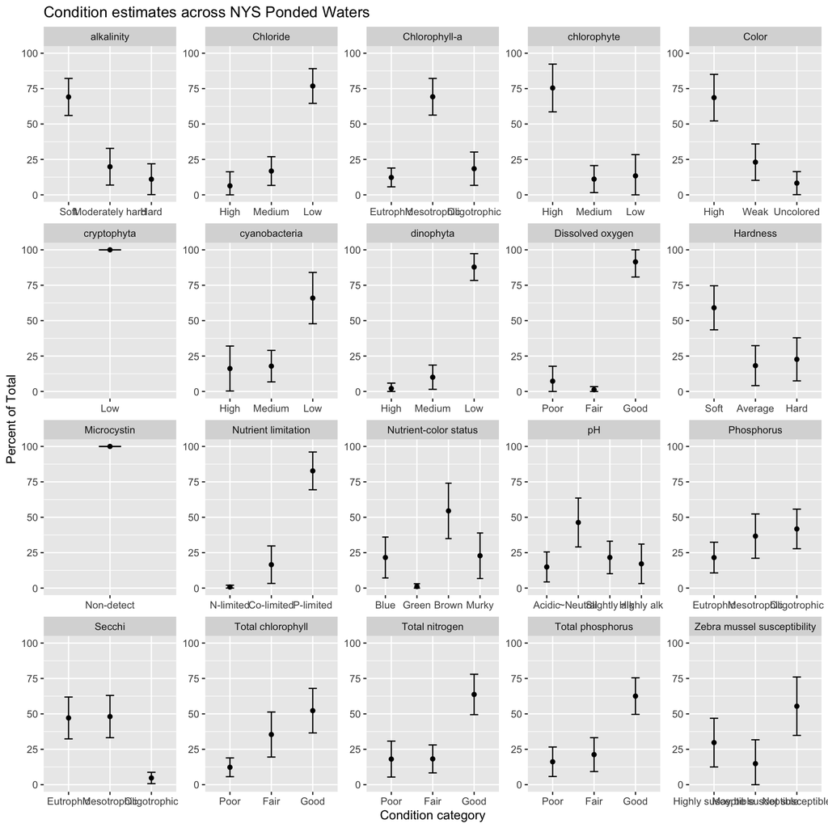

```r
ggplot(table,aes(x=Category,y=Estimate.P)) +
  geom_point()+
  geom_errorbar(aes(ymin=LCB95Pct.P,ymax=UCB95Pct.P),width=0.2)+
  theme(legend.position = "none")+
  facet_wrap(.~Indicator,scales = "free")+
  ylim(0,100)+
  labs(title="Condition estimates across NYS Ponded Waters",y="Percent of Total",x="Condition category")
```

### Category bar plot

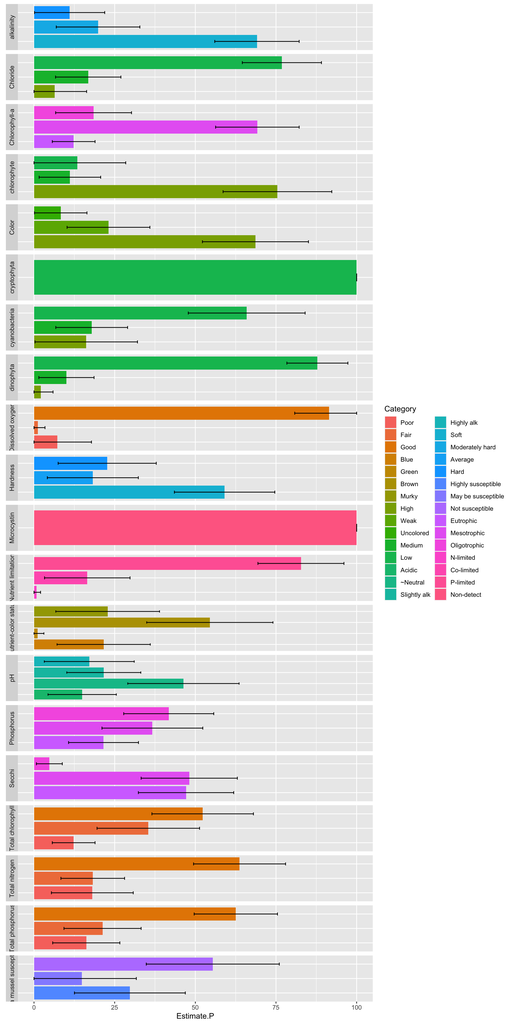

```r
# All
ggplot(table,aes(y=Estimate.P,x=Category,fill=Category))+
  geom_col()+
  ylim(0,100)+
  geom_errorbar(aes(ymin=LCB95Pct.P,ymax=UCB95Pct.P),width=0.2)+
  coord_flip()+
  theme(axis.title.y = element_blank(), axis.text.y = element_blank(),axis.ticks.y = element_blank())+
  facet_wrap(.~Indicator,scales = "free_y",ncol=1,strip.position = "left")
```

### Cumulative distribution function

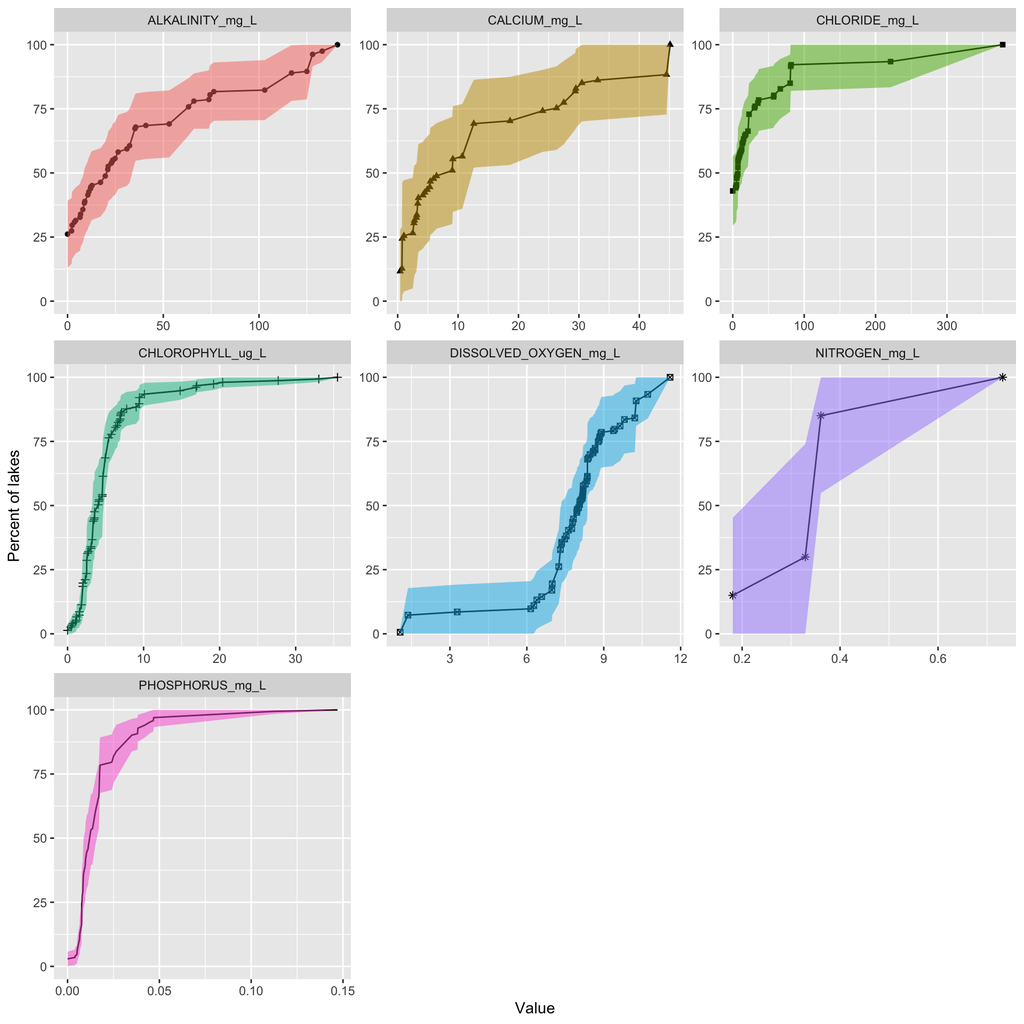

```r
#To plot a cumulative distribution function:
ggplot(analysis$CDF,aes(x=Value,y=Estimate.P,fill=Indicator,shape=Indicator,ymin=LCB95Pct.P,ymax=UCB95Pct.P))+
  geom_line()+
  geom_point()+
  geom_ribbon(alpha=0.5)+
  ylim(0,100)+
  facet_wrap(.~Indicator, scales="free")+
  guides(fill=FALSE,shape=FALSE)+
  labs(y="Percent of lakes")
```

### Map

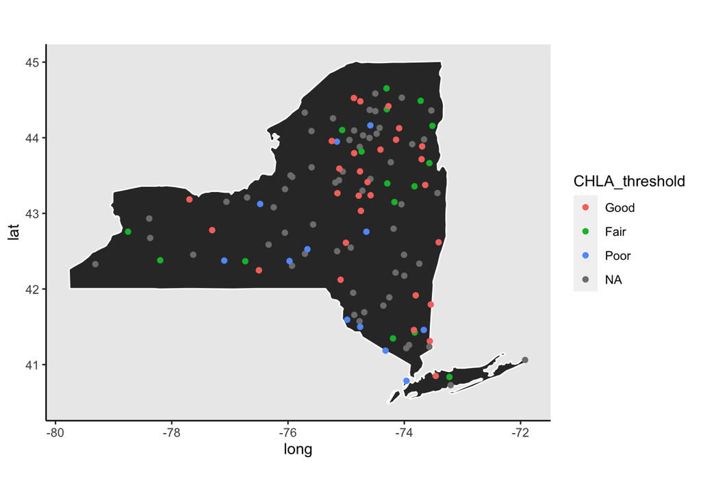

```r
#fetch map
library(ggmap)
library(maps)

states <- map_data("state")
ny <- subset(states, region %in% c("new york"))

att$CHLA_threshold <- factor(att$CHLA_threshold, levels=c("Good","Fair","Poor"))
ggplot() +
  geom_polygon(data=ny,aes(x = long, y = lat, group = group), color = "white") +
  coord_fixed(1.3) +
  geom_point(data=att,aes(x=xcoord,y=ycoord,color=CHLA_threshold))+
  guides(fill=FALSE)+
  theme(panel.border = element_blank(), panel.grid.major = element_blank(),
        panel.grid.minor = element_blank(), axis.line = element_line(colour = "black"))
```

## Comparisons

Compare with NLA, Northern Appalachian and New Hampshire.

### Category dot plot

```
## During execution of the program, 3 warning messages were generated.  The warning
## messages are stored in a data frame named 'warn_df'.  Enter the following
## command to view the warning messages: warnprnt()
## To view a subset of the warning messages (say, messages number 1, 3, and 5),
## enter the following command: warnprnt(m=c(1,3,5))
```

```
## During execution of the program, a warning message was generated.  The warning
## message is stored in a data frame named 'warn_df'.  Enter the following command
## to view the warning message: warnprnt()
```

```
## During execution of the program, 10 warning messages were generated.  The warning
## messages are stored in a data frame named 'warn_df'.  Enter the following
## command to view the warning messages: warnprnt()
## To view a subset of the warning messages (say, messages number 1, 3, and 5),
## enter the following command: warnprnt(m=c(1,3,5))
```

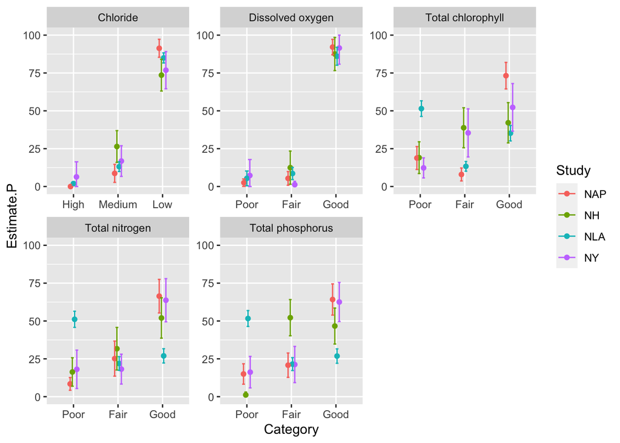

```r
cats <- rbind(ny.cat,nh.cat,nla.cat,nap.cat)

ggplot(cats,aes(x=Category,y=Estimate.P,color=Study))+
  geom_point(position=position_dodge(width=0.2))+
  ylim(0,100)+
  geom_errorbar(aes(ymin=LCB95Pct.P, ymax=UCB95Pct.P), width=.25, position=position_dodge(width=0.2))+
  facet_wrap(.~Indicator, scales="free")
```

### Cumulative distribution function

```
## During execution of the program, a warning message was generated.  The warning
## message is stored in a data frame named 'warn_df'.  Enter the following command
## to view the warning message: warnprnt()
```

```
## During execution of the program, 4 warning messages were generated.  The warning
## messages are stored in a data frame named 'warn_df'.  Enter the following
## command to view the warning messages: warnprnt()
## To view a subset of the warning messages (say, messages number 1, 3, and 5),
## enter the following command: warnprnt(m=c(1,3,5))
```

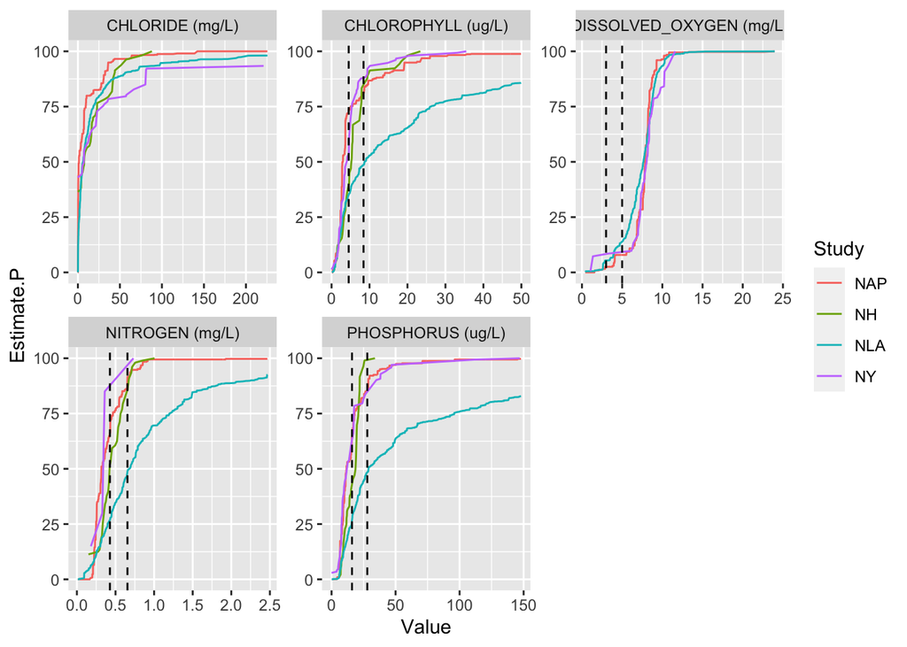

```r
ggplot(all,aes(x=Value,y=Estimate.P,color=Study,shape=Study))+
  geom_line()+
  ylim(0,100)+
  geom_vline(data=table,aes(xintercept=Low),linetype="dashed")+
  geom_vline(data=table,aes(xintercept=High),linetype="dashed")+
  facet_wrap(.~Indicator, scales="free")
```